# Cafe 市場調查專案

## [致謝].

> - 謹以此份專案紀念我的恩師: **周文賢 教授**
> - 感謝老師無私的奉獻，學生受益良多

## [說明]

> 這是一份正式的市場調查專案，主要協助業主(左岸咖啡)了解市場產品定位

## [問卷代碼編號]

Label No ="問卷代碼"

#### 【第 A 部份】包裝咖啡之使用及購買行為

A101="左岸頻率" A102="伯朗頻率" A103="廣場頻率" A104="輕鬆頻率"  
A2 ="咖啡偏好" A3 ="偏好口味"

A401="提神醒腦" A402="習慣飲用" A403="抒解口渴" A404="換喝飲料" A405="特殊口感" A406="享受感覺"  
A501="知名度高" A502="廣告感覺" A503="價格合理" A504="包裝美觀" A505="整體口感"

A611="左岸知名" A612="左岸廣告" A613="左岸價格" A614="左岸包裝" A615="左岸口感"  
A621="伯朗知名" A622="伯朗廣告" A623="伯朗價格" A624="伯朗包裝" A625="伯朗口感"  
A631="廣場知名" A632="廣場廣告" A633="廣場價格" A634="廣場包裝" A635="廣場口感"  
A641="輕鬆知名" A642="輕鬆廣告" A643="輕鬆價格" A644="輕鬆包裝" A645="輕鬆口感"

A701="猶豫程度" A702="後悔程度" A703="詢問程度" A704="關心程度" A705="注意程度" A706="選對重要"  
A801="產品重要" A802="自我概念" A803="象徵價值" A804="商店忠誠(逆)" A805="品牌忠誠" A806="品牌信念(逆)"  
A901="產品質佳" A902="積極開發" A903="重視權益"

#### 【第 B 部份】左岸咖啡之使用及購買行為

B1 ="訊息接觸"  
B201="口味香醇" B202="浪漫生活" B203="提振精神" B204="氣質優雅"  
B301="廣告印象" B302="廣告說服" B303="廣告吸引" B304="廣告訊息"  
B401="左岸意義" B402="左岸口味" B403="左岸價格" B404="左岸包裝"  
B501="產品優質" B502="令人喜歡" B503="正面評價"  
B6 ="促銷方案"

#### 【第 C 部份】生活型態

C01 ="閱讀報章" C02 ="戶外活動" C03="價格敏感"  
C04 ="偏好家居" C05 ="經常運動" C06="流行資訊"  
C07 ="獨自工作" C08 ="重視休閒" C09="重視品牌"  
C10 ="希望讚美" C11 ="朋友聚會" C12="重視外觀"  
C13 ="工作時長" C14 ="政治冷漠" C15="社會憂心"

#### 【第 D 部份】個人基本資料

Sex ="性別" AGE ="年齡" Occupatn="職業"  
Edu ="教育程度" Income0="所得" Income ="調整後所得"  
Area="居住地區" Intenst="產品強度";

## [標準開始動作]. 如果你用python的目標是科學計算或數值分析，基本是引⼊三個套件

```python
%matplotlib inline
##將後續畫圖的結果直接顯現在網頁中

import numpy as np
import matplotlib.pyplot as plt
import pandas as pd  #
```

## [PART 1].輸入資料與資料檢查

```python
import xlrd #讀取excel檔的模板
excel_file = 'Pycafe.xlsx'
Cafe = pd.read_excel(excel_file)
```

```python
print(Cafe.shape)# 印出資料維度
```

```
(40, 93)
```

```python
print(Cafe.info())# 印出 DataFrame 資料概況, 順便check有沒有missing value
```

```
<class 'pandas.core.frame.DataFrame'>
RangeIndex: 40 entries, 0 to 39
Data columns (total 93 columns):
ID             40 non-null int64
A101左岸頻率       40 non-null int64
A102伯朗頻率       40 non-null int64
A103廣場頻率       40 non-null int64
A104輕鬆頻率       40 non-null int64
A2咖啡偏好         40 non-null int64
A3偏好口味         40 non-null object
A401提神醒腦       40 non-null int64
A402習慣飲用       40 non-null int64
A403抒解口渴       40 non-null int64
A404換喝飲料       40 non-null int64
A405特殊口感       40 non-null int64
A406享受感覺       40 non-null int64
A501知名度高       40 non-null int64
A502廣告感覺       40 non-null int64
A503價格合理       40 non-null int64
A504包裝美觀       40 non-null int64
A505整體口感       40 non-null int64
A611左岸知名       40 non-null int64
A612左岸廣告       40 non-null int64
A613左岸價格       40 non-null int64
A614左岸包裝       40 non-null int64
A615左岸口感       40 non-null int64
A621伯朗知名       40 non-null int64
A622伯朗廣告       40 non-null int64
A623伯朗價格       40 non-null int64
A624伯朗包裝       40 non-null int64
A625伯朗口感       40 non-null int64
A631廣場知名       40 non-null int64
A632廣場廣告       40 non-null int64
A633廣場價格       40 non-null int64
A634廣場包裝       40 non-null int64
A635廣場口感       40 non-null int64
A641輕鬆知名       40 non-null int64
A642輕鬆廣告       40 non-null int64
A643輕鬆價格       40 non-null int64
A644輕鬆包裝       40 non-null int64
```

[output cut: 44 more lines]

```
C12重視外觀        40 non-null int64
C13工作時長        40 non-null int64
C14政治冷漠        40 non-null int64
C15社會憂心        40 non-null int64
Sex            40 non-null object
AGE            40 non-null int64
Occupatn       40 non-null object
Edu            40 non-null object
Income0        40 non-null object
IncomeMd       40 non-null float64
Area           40 non-null object
Intenst        40 non-null float64
dtypes: float64(2), int64(85), object(6)
memory usage: 29.1+ KB
None
```

```python
Cafe.head() #看前五筆資料
```

|  | ID | A101左岸頻率 | A102伯朗頻率 | A103廣場頻率 | A104輕鬆頻率 | A2咖啡偏好 | A3偏好口味 | A401提神醒腦 | A402習慣飲用 | A403抒解口渴 | ... | C14政治冷漠 | C15社會憂心 | Sex | AGE | Occupatn | Edu | Income0 | IncomeMd | Area | Intenst |
| --- | --- | --- | --- | --- | --- | --- | --- | --- | --- | --- | --- | --- | --- | --- | --- | --- | --- | --- | --- | --- | --- |
| 0 | 1 | 3 | 0 | 1 | 0 | 6 | 加糖及奶精之香濃口味 | 4 | 3 | 2 | ... | 2 | 6 | 女 | 5 | 自營企業 | 研究所 | 6萬以上 | 6.5 | 北部 | 94.8848 |
| 1 | 2 | 1 | 0 | 0 | 0 | 1 | 加糖及奶精之香濃口味 | 4 | 3 | 4 | ... | 2 | 6 | 女 | 5 | 其他 | 研究所 | 3-4萬 | 3.5 | 北部 | 17.0509 |
| 2 | 3 | 0 | 2 | 0 | 0 | 2 | 偏苦之咖啡原味 | 6 | 5 | 4 | ... | 2 | 6 | 男 | 4 | 其他 | 專科及大學 | 2-3萬 | 2.5 | 北部 | 10.0137 |
| 3 | 4 | 2 | 0 | 3 | 0 | 7 | 加糖及奶精之香濃口味 | 7 | 6 | 4 | ... | 1 | 7 | 女 | 3 | 白領階層 | 專科及大學 | 4-5萬 | 4.5 | 北部 | 90.4082 |
| 4 | 5 | 1 | 0 | 0 | 0 | 1 | 加糖及奶精之香濃口味 | 3 | 3 | 3 | ... | 4 | 5 | 女 | 2 | 藍領階層 | 國中 | 1-2萬 | 1.5 | 北部 | 17.0509 |

5 rows × 93 columns

```python
Cafe.tail() #看後面幾筆
```

|  | ID | A101左岸頻率 | A102伯朗頻率 | A103廣場頻率 | A104輕鬆頻率 | A2咖啡偏好 | A3偏好口味 | A401提神醒腦 | A402習慣飲用 | A403抒解口渴 | ... | C14政治冷漠 | C15社會憂心 | Sex | AGE | Occupatn | Edu | Income0 | IncomeMd | Area | Intenst |
| --- | --- | --- | --- | --- | --- | --- | --- | --- | --- | --- | --- | --- | --- | --- | --- | --- | --- | --- | --- | --- | --- |
| 35 | 36 | 1 | 0 | 2 | 0 | 6 | 加糖及奶精之香濃口味 | 6 | 6 | 4 | ... | 5 | 3 | 男 | 4 | 自營企業 | 高中(職) | 6萬以上 | 6.5 | 南部 | 66.4761 |
| 36 | 37 | 0 | 1 | 0 | 0 | 1 | 加糖及奶精之香濃口味 | 6 | 5 | 4 | ... | 7 | 3 | 女 | 5 | 其他 | 國中 | 1-2萬 | 1.5 | 南部 | 5.9818 |
| 37 | 38 | 0 | 1 | 0 | 0 | 6 | 加糖及奶精之香濃口味 | 6 | 5 | 4 | ... | 6 | 3 | 女 | 1 | 學生 | 國中 | 2-3萬 | 2.5 | 中部 | 42.9104 |
| 38 | 39 | 2 | 0 | 1 | 0 | 5 | 加糖及奶精之香濃口味 | 5 | 5 | 3 | ... | 3 | 6 | 女 | 3 | 白領階層 | 高中(職) | 5-6萬 | 5.5 | 中部 | 77.4608 |
| 39 | 40 | 0 | 2 | 0 | 0 | 3 | 加糖及奶精之香濃口味 | 7 | 6 | 3 | ... | 5 | 4 | 女 | 4 | 其他 | 專科及大學 | 1-2萬 | 1.5 | 中部 | 15.7390 |

5 rows × 93 columns

```python
Cafe.sample(10)#隨機取10行
```

|  | ID | A101左岸頻率 | A102伯朗頻率 | A103廣場頻率 | A104輕鬆頻率 | A2咖啡偏好 | A3偏好口味 | A401提神醒腦 | A402習慣飲用 | A403抒解口渴 | ... | C14政治冷漠 | C15社會憂心 | Sex | AGE | Occupatn | Edu | Income0 | IncomeMd | Area | Intenst |
| --- | --- | --- | --- | --- | --- | --- | --- | --- | --- | --- | --- | --- | --- | --- | --- | --- | --- | --- | --- | --- | --- |
| 22 | 23 | 1 | 0 | 0 | 2 | 6 | 加糖及奶精之香濃口味 | 6 | 6 | 3 | ... | 5 | 4 | 男 | 3 | 白領階層 | 專科及大學 | 3-4萬 | 3.5 | 北部 | 66.4761 |
| 36 | 37 | 0 | 1 | 0 | 0 | 1 | 加糖及奶精之香濃口味 | 6 | 5 | 4 | ... | 7 | 3 | 女 | 5 | 其他 | 國中 | 1-2萬 | 1.5 | 南部 | 5.9818 |
| 17 | 18 | 2 | 1 | 1 | 0 | 6 | 加糖及奶精之香濃口味 | 6 | 6 | 3 | ... | 2 | 5 | 男 | 4 | 自營企業 | 研究所 | 6萬以上 | 6.5 | 北部 | 84.8410 |
| 10 | 11 | 2 | 3 | 0 | 0 | 7 | 加糖及奶精之香濃口味 | 7 | 7 | 3 | ... | 4 | 5 | 女 | 4 | 白領階層 | 高中(職) | 4-5萬 | 4.5 | 南部 | 90.4082 |
| 25 | 26 | 1 | 0 | 0 | 2 | 6 | 加糖及奶精之香濃口味 | 6 | 6 | 3 | ... | 5 | 4 | 男 | 3 | 白領階層 | 專科及大學 | 3-4萬 | 3.5 | 北部 | 66.4761 |
| 9 | 10 | 2 | 1 | 1 | 0 | 4 | 加糖及奶精之香濃口味 | 5 | 6 | 2 | ... | 4 | 4 | 男 | 4 | 藍領階層 | 專科及大學 | 2-3萬 | 2.5 | 北部 | 68.3881 |
| 1 | 2 | 1 | 0 | 0 | 0 | 1 | 加糖及奶精之香濃口味 | 4 | 3 | 4 | ... | 2 | 6 | 女 | 5 | 其他 | 研究所 | 3-4萬 | 3.5 | 北部 | 17.0509 |
| 33 | 34 | 0 | 1 | 0 | 2 | 7 | 偏苦之咖啡原味 | 7 | 7 | 5 | ... | 4 | 6 | 女 | 1 | 學生 | 國中 | 1-2萬 | 1.5 | 南部 | 53.8586 |
| 37 | 38 | 0 | 1 | 0 | 0 | 6 | 加糖及奶精之香濃口味 | 6 | 5 | 4 | ... | 6 | 3 | 女 | 1 | 學生 | 國中 | 2-3萬 | 2.5 | 中部 | 42.9104 |
| 8 | 9 | 0 | 1 | 0 | 0 | 1 | 偏苦之咖啡原味 | 6 | 5 | 4 | ... | 5 | 5 | 女 | 2 | 藍領階層 | 高中(職) | 2-3萬 | 2.5 | 北部 | 5.9818 |

10 rows × 93 columns

## [PART 2].基本敘述性統計

> 一般而言，一開始我們會從人口統計資料開始看起

```python
Cafe.describe() #基本統計量, 但這種方法只能看全部，無法只看你想看的欄位(同時只會顯示量化資料)
```

|  | ID | A101左岸頻率 | A102伯朗頻率 | A103廣場頻率 | A104輕鬆頻率 | A2咖啡偏好 | A401提神醒腦 | A402習慣飲用 | A403抒解口渴 | A404換喝飲料 | ... | C09重視品牌 | C10希望讚美 | C11朋友聚會 | C12重視外觀 | C13工作時長 | C14政治冷漠 | C15社會憂心 | AGE | IncomeMd | Intenst |
| --- | --- | --- | --- | --- | --- | --- | --- | --- | --- | --- | --- | --- | --- | --- | --- | --- | --- | --- | --- | --- | --- |
| count | 40.000000 | 40.000000 | 40.000000 | 40.00000 | 40.000000 | 40.000000 | 40.000000 | 40.000000 | 40.000000 | 40.000000 | ... | 40.000000 | 40.00000 | 40.000000 | 40.000000 | 40.000000 | 40.000000 | 40.000000 | 40.000000 | 40.000000 | 40.000000 |
| mean | 20.500000 | 0.900000 | 0.825000 | 0.52500 | 0.300000 | 4.675000 | 5.650000 | 5.325000 | 3.550000 | 4.875000 | ... | 5.025000 | 5.15000 | 4.875000 | 4.850000 | 5.800000 | 4.000000 | 4.850000 | 3.275000 | 3.275000 | 49.750510 |
| std | 11.690452 | 0.981887 | 0.873763 | 0.84694 | 0.686873 | 2.152965 | 1.188621 | 1.141018 | 0.814925 | 1.264658 | ... | 1.270726 | 1.16685 | 1.362266 | 1.271986 | 1.471089 | 1.281025 | 1.144664 | 1.219237 | 1.624926 | 31.182213 |
| min | 1.000000 | 0.000000 | 0.000000 | 0.00000 | 0.000000 | 1.000000 | 3.000000 | 3.000000 | 2.000000 | 3.000000 | ... | 3.000000 | 3.00000 | 2.000000 | 2.000000 | 1.000000 | 1.000000 | 3.000000 | 1.000000 | 0.500000 | 5.981800 |
| 25% | 10.750000 | 0.000000 | 0.000000 | 0.00000 | 0.000000 | 2.750000 | 5.000000 | 5.000000 | 3.000000 | 4.000000 | ... | 4.000000 | 4.00000 | 4.000000 | 4.000000 | 5.000000 | 3.750000 | 4.000000 | 2.000000 | 2.250000 | 16.722925 |
| 50% | 20.500000 | 1.000000 | 1.000000 | 0.00000 | 0.000000 | 6.000000 | 6.000000 | 5.000000 | 4.000000 | 5.000000 | ... | 5.500000 | 5.00000 | 5.000000 | 5.000000 | 6.000000 | 4.000000 | 5.000000 | 3.000000 | 2.500000 | 49.431150 |
| 75% | 30.250000 | 2.000000 | 1.000000 | 1.00000 | 0.000000 | 6.250000 | 7.000000 | 6.000000 | 4.000000 | 6.000000 | ... | 6.000000 | 6.00000 | 6.000000 | 6.000000 | 7.000000 | 5.000000 | 6.000000 | 4.000000 | 4.500000 | 79.305850 |
| max | 40.000000 | 3.000000 | 3.000000 | 3.00000 | 2.000000 | 7.000000 | 7.000000 | 7.000000 | 5.000000 | 7.000000 | ... | 7.000000 | 7.00000 | 7.000000 | 7.000000 | 7.000000 | 7.000000 | 7.000000 | 5.000000 | 6.500000 | 97.188900 |

8 rows × 87 columns

## [2-1]. 次數分配表(交叉分析)

```python
Cafe['Sex'].value_counts() #計算一下男女的分佈
```

```
女    21
男    19
Name: Sex, dtype: int64
```

```python
Cafe['Edu'].value_counts() #計算一下學歷的分佈
```

```
專科及大學    16
高中(職)    13
研究所       6
國中        5
Name: Edu, dtype: int64
```

```python
result = Cafe['IncomeMd'].describe() #計算調整後的所得之敘述統計量
pd.DataFrame(result )   #格式化成DataFrame
```

|  | IncomeMd |
| --- | --- |
| count | 40.000000 |
| mean | 3.275000 |
| std | 1.624926 |
| min | 0.500000 |
| 25% | 2.250000 |
| 50% | 2.500000 |
| 75% | 4.500000 |
| max | 6.500000 |

```python
Cross0 = pd.crosstab(Cafe['Sex'], Cafe['Edu']) #建立交叉列聯表
Cross0
```

| Edu Sex | 國中 | 專科及大學 | 研究所 | 高中(職) |
| --- | --- | --- | --- | --- |
| 女 | 4 | 6 | 3 | 8 |
| 男 | 1 | 10 | 3 | 5 |

```python
Cross1 = pd.crosstab(Cafe['Sex'], Cafe['A3偏好口味']) #建立交叉列聯表
Cross1
```

| A3偏好口味 Sex | 偏苦之咖啡原味 | 加糖及奶精之香濃口味 |
| --- | --- | --- |
| 女 | 3 | 18 |
| 男 | 11 | 8 |

```python
Cross2 = pd.crosstab(Cafe['Area'], Cafe['A3偏好口味']) #建立交叉列聯表
Cross2
```

| A3偏好口味 Area | 偏苦之咖啡原味 | 加糖及奶精之香濃口味 |
| --- | --- | --- |
| 中部 | 1 | 6 |
| 南部 | 4 | 6 |
| 北部 | 9 | 14 |

```python
#我們可以採取一些更進階的交叉分析表

Cross3 = pd.crosstab(index=[Cafe['Area'], Cafe['Sex']],
                    columns=Cafe["A3偏好口味"]
                             )
Cross3
```

| Area | A3偏好口味 Sex | 偏苦之咖啡原味 | 加糖及奶精之香濃口味 |
| --- | --- | --- | --- |
| 中部 | 女 | 0 | 6 |
|  | 男 | 1 | 0 |
| 南部 | 女 | 1 | 3 |
|  | 男 | 3 | 3 |
| 北部 | 女 | 2 | 9 |
|  | 男 | 7 | 5 |

### [小結]

- **女生喜歡"加糖及奶精之香濃口味"; 男生喜歡"偏苦之咖啡原味"**
- **南北部在口味偏好的比例上，大約是2:3左右的比例(偏苦之咖啡原味 : 加糖及奶精之香濃口味)，顯示"加糖及奶精之香濃口味"在比例上較高**
- **承上，北部的男性，在偏好口味上未必有顯著差異，但女性則有**

## [2-2]. 樞紐分析表(Pivot Table)

通常一般敘述性統計我們就只能看看單一變數的基本狀況，若我們想要倆倆比較一下，則比較適合用樞紐分析表

```python
Cafe.pivot_table('IncomeMd', index='Sex', columns='Occupatn') #樞紐分析表
```

| Occupatn Sex | 其他 | 學生 | 白領階層 | 自營企業 | 藍領階層 |
| --- | --- | --- | --- | --- | --- |
| 女 | 1.90 | 2.0 | 4.928571 | 5.500000 | 2.300000 |
| 男 | 2.25 | 1.5 | 3.666667 | 6.166667 | 2.166667 |

```python
 Cafe.pivot_table('IncomeMd', index='Occupatn', columns='Area') #樞紐分析表
```

| Area Occupatn | 中部 | 南部 | 北部 |
| --- | --- | --- | --- |
| 其他 | 1.5 | 1.500000 | 2.333333 |
| 學生 | 1.5 | 1.833333 | NaN |
| 白領階層 | 5.5 | 4.166667 | 3.928571 |
| 自營企業 | NaN | 6.000000 | 5.833333 |
| 藍領階層 | NaN | 2.500000 | 2.214286 |

## [2-3].資料視覺化

- **雖然上述我們採用部分人口統計資料進行初探，但其實你也可以畫畫圖來進行EDA(Exploratory Data Analysis，簡稱EDA)**

### Python資料視覺化主要有三大套件：

- 'Matplotlib': 指令功能齊全，歷史最悠久的套件，己乎沒有圖示畫不出來的，但也最複雜
- 'Seaborn': 是在Matplot的基礎上實作更高階的視覺化API，可以讓畫圖變得更方便、容易。
- 'Plotly': 好看的各種視覺化圖表，可做出互動化的介面。但Plotly並沒有在Anaconda裡面，所以要在先下pip install plotly進行安裝

### [補充1]

`matplotlib` 幾乎是標準 Python 畫圖套件! 在有 `matplotlib` 之前, Python 要畫圖不那麼方便, 和 Python 很多套件一樣, 有許多方案, 但各家有不同的優缺點, 也沒有一套是大家都在用的。

而 `matplotlib` 仿 Matlab 式的畫圖方式, 讓很多人很快入手、並且功能相當完整。原作者是 John D. Hunter, 和很多 Python 的套件作者一樣, 他有博士學位。非常令人遺憾的是他在 2012 年因大腸直腸癌治療併發症過逝, 過逝時才 44 歲!

### [補充2].字形編碼問題

- 在matplotlib 或 Seaborn 中，對於中文必須特別設定，否則圖不會顯示中文
- 請採用以下設定，請參考

https://medium.com/marketingdatascience/%E8%A7%A3%E6%B1%BApython-3-matplotlib%E8%88%87seaborn%E8%A6%96%E8%A6%BA%E5%8C%96%E5%A5%97%E4%BB%B6%E4%B8%AD%E6%96%87%E9%A1%AF%E7%A4%BA%E5%95%8F%E9%A1%8C-f7b3773a889b

- 建議:
  - Mac可用字體：SimHei
  - Windows 可用字體：Microsoft JhengHei

### [2-3-1]. 散佈圖

```python
#基礎設定
from matplotlib.font_manager import FontProperties
import seaborn as sns
myfont=FontProperties(fname=r'C:\Users\user\Anaconda3\lib\site-packages\matplotlib\mpl-data\fonts\ttf\msj.ttf',size=14)
sns.set(font=myfont.get_family())
sns.set_style("whitegrid",{"font.sans-serif":['Microsoft JhengHei']})
```

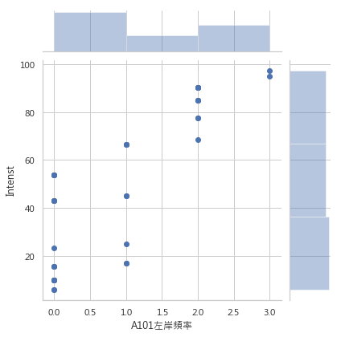

```python
sns.jointplot(x = "A101左岸頻率", y = "Intenst", data = Cafe)#散佈圖
```

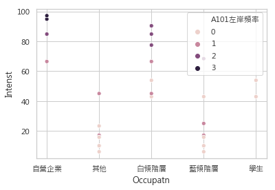

```python
sns.scatterplot(x="Occupatn", y="Intenst",
                hue="A101左岸頻率",
                data=Cafe)
```

### [2-3-2].次數分配圖

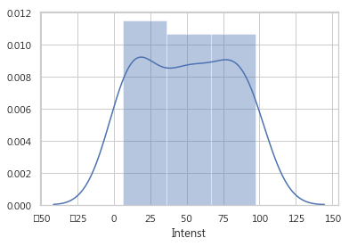

```python
#distplot的變數只能放數量資料
sns.distplot(Cafe['Intenst']) #產品強度的次數分佈
```

### [2-3-3].次數分配圖(count plot)

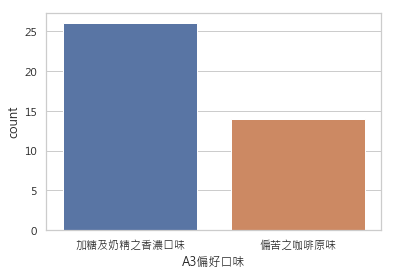

```python
# countplot放屬質資料
sns.countplot(x = "A3偏好口味", data=Cafe)
```

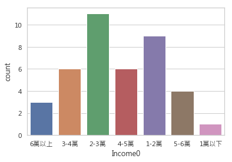

```python
sns.countplot(x = "Income0", data=Cafe)
```

### [2-3-4]. Bar-Plot

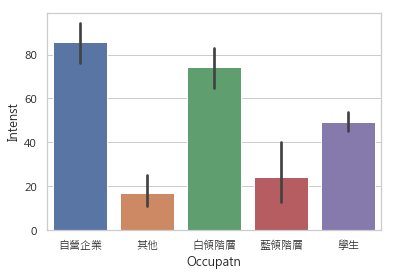

```python
sns.barplot(x="Occupatn", y="Intenst", data=Cafe)
```

### [小結].**自營企業的產品強度最高，其他與藍領偏低**

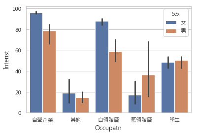

```python
sns.barplot(x="Occupatn", y="Intenst", hue="Sex", data=Cafe)
```

### **自營企業與白領階層，都是女性的產品強度較高 ; 但在藍領階層則為男性的產品強度較高**

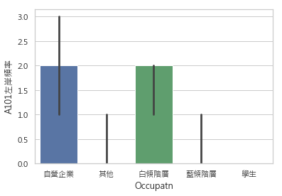

```python
from numpy import median
sns.barplot(x="Occupatn", y="A101左岸頻率", data=Cafe, estimator=median) #用每天的中位數去估計小費的高低
```

### [2-3-5]. Box-Plot

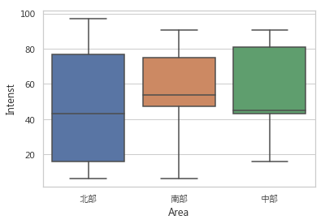

```python
sns.boxplot(x = 'Area', y= 'Intenst', data = Cafe)
```

### 中部的產品強度Q1與Q2非常接近，可能需要額外進行資料探討，因此我們可以嘗試加入其他變數看看，如下圖:

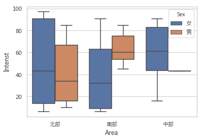

```python
sns.boxplot(x = 'Area', y= 'Intenst', data = Cafe, hue = 'Sex') # hue = 'sex'以性別當圖標
```

### [2-3-6]. Cat-Plot

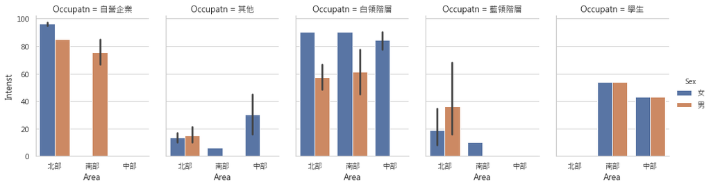

```python
#這是進階語法，可一次看多個
sns.catplot(x="Area", y="Intenst",
            hue="Sex", col="Occupatn",
            data=Cafe, kind="bar",
            height=4, aspect=.7)
```

## [2-4]. 相關係數矩陣

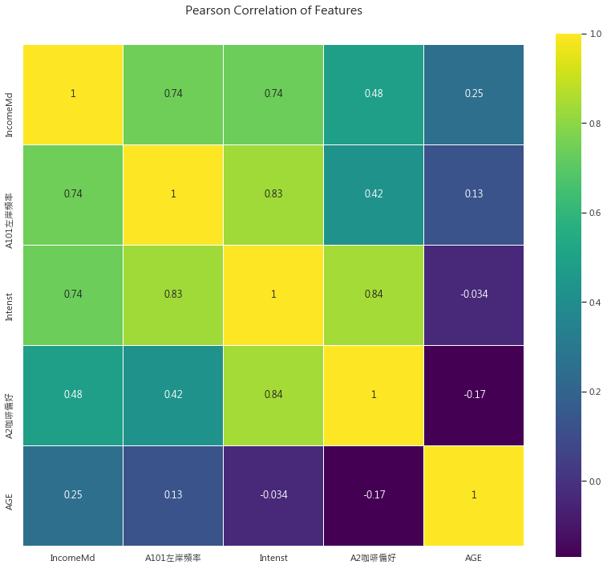

```python
colormap = plt.cm.viridis
plt.figure(figsize=(14,12))
plt.title('Pearson Correlation of Features', y=1.05, size=15)
sns.heatmap(Cafe[['IncomeMd', 'A101左岸頻率', 'Intenst', 'A2咖啡偏好', 'AGE']].astype(float).corr(),linewidths=0.1,vmax=1.0, square=True, cmap=colormap, linecolor='white', annot=True)
```

## [PART 3]. 產品消費頻率、性別與生活型態之探討

- 本文的目的在於解決左岸咖啡的產品偏好與消費者行為等問題，因此在本小節將交叉使用卡方分析、變異數分析與迴歸分析等統計工具

## [3-1]. T檢定

```python
Cafe.A101左岸頻率.describe()
```

```
count    40.000000
mean      0.900000
std       0.981887
min       0.000000
25%       0.000000
50%       1.000000
75%       2.000000
max       3.000000
Name: A101左岸頻率, dtype: float64
```

```python
Cafe.A102伯朗頻率.describe()
```

```
count    40.000000
mean      0.825000
std       0.873763
min       0.000000
25%       0.000000
50%       1.000000
75%       1.000000
max       3.000000
Name: A102伯朗頻率, dtype: float64
```

### 近一週飲用包裝咖啡之瓶/罐數上，我們發現左岸咖啡與伯朗咖啡的平均飲用頻率不同，因此我們可以採用平均數檢定

- **H0a:左岸咖啡與伯朗咖啡的飲用頻率相同**
- **H1a:左岸咖啡與伯朗咖啡的飲用頻率不同**

```python
# two sample student t test

import numpy as np
from scipy import stats

mean1 = 0.9 #左岸頻率
mean2 = 0.825 #伯朗頻率

std1 = 0.981887
std2 = 0.873763

nobs1 = 40 #觀察值
nobs2 = 40

modified_std1 = np.sqrt(np.float64(nobs1)/np.float64(nobs1-1)) * std1
modified_std2 = np.sqrt(np.float64(nobs2)/np.float64(nobs2-1)) * std2

(statistic, pvalue) = stats.ttest_ind_from_stats(mean1=mean1, std1=modified_std1, nobs1=40, mean2=mean2, std2=modified_std2, nobs2=40)

print("t statistic is: ", statistic)
print("pvalue is: ", pvalue)
```

```
t statistic is:  0.35634979368627523
pvalue is:  0.7225407335164281
```

## [3-2].Independent t-test

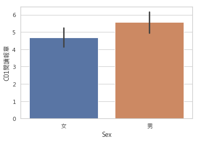

```python
sns.barplot(x="Sex", y="C01閱讀報章", data=Cafe) #以"閱讀報章"為範例
```

### Q: H0b:性別對部份生活型態有無差異?

- **H0b: 性別對閱讀報章之生活型態沒有差異**
- **H1b: 性別對閱讀報章之生活型態有差異**

```python
Cafe["Gender"] = Cafe[["Sex"]] #新增一個 Gender欄位，內容是Sex的內容
Cafe.Gender.sample(10)#隨機取10行
```

```
22    男
23    男
12    女
2     男
5     女
25    男
11    男
7     男
1     女
31    男
Name: Gender, dtype: object
```

```python
from scipy.stats import ttest_ind

males = Cafe[Cafe['Gender']=='男']
females = Cafe[Cafe['Gender']=='女']
stats.ttest_ind(males['C01閱讀報章'], females['C01閱讀報章'])
#ttest_ind(males['C01閱讀報章'], females['C01閱讀報章'], nan_policy='omit')
```

```
Ttest_indResult(statistic=2.1650845805362673, pvalue=0.03672691814441933)
```

### [小結]. **Reject H0。在α = 0.05下，我們有顯著的證據認為，性別對閱讀報章之生活型態有差異**

## [PART 4]. 左岸咖啡之市場區隔及目標選擇決策

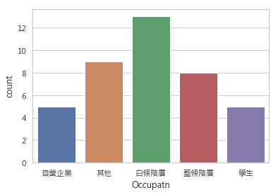

```python
sns.countplot(x = "Occupatn", data=Cafe)
```

## [4-1]. One-Way ANOVA: 左岸咖啡之市場區隔及目標選擇決策

- **H0c: 職業對產品強度沒有影響**
- **H1c: 職業對產品強度有影響**

```python
#create an Ordinary Least Squares (OLS) model as a precursor to the ANOVA.
from scipy import stats
import statsmodels
import statsmodels.api as sm
from statsmodels.formula.api import ols
```

```python
model = ols('Intenst ~ Occupatn', Cafe).fit() #builds the OLS model, predicting weight loss with diet type.
```

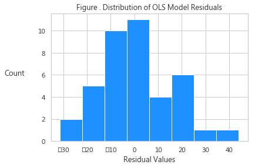

```python
resids = statsmodels.regression.linear_model.RegressionResults.resid(model) # grabs the residual values from the OLS model
hist2 = plt.hist(resids, bins = 'auto', color='dodgerblue') # check for variable normality in weight loss dependent variable.
#Data looks normally distributed.
plt.title("Figure . Distribution of OLS Model Residuals")
plt.xlabel("Residual Values")
plt.ylabel("Count", rotation = 0, labelpad = 40)
plt.show()
```

```python
table = sm.stats.anova_lm(model, typ=2) # Type 2 ANOVA DataFrame
print(table)
```

```
                sum_sq    df          F        PR(>F)
Occupatn  29122.702854   4.0  28.963215  1.137793e-10
Residual   8798.182431  35.0        NaN           NaN
```

### Reject H0。在α = 0.05下，我們有顯著的證據認為，職業對產品強度有差異。但是職業對產品強度有差異，但究竟誰高誰低，兩兩之間誰跟誰有差異? 我們需要進行ANOVA的事後多重比較

## [4-2].ANOVA的事後多重比較(以Tukey test 為例)

```python
from statsmodels.stats.multicomp import pairwise_tukeyhsd
from statsmodels.stats.multicomp import MultiComparison

mc = MultiComparison(Cafe['Intenst'], Cafe['Occupatn'])
tkresult = mc.tukeyhsd()

print(tkresult)
```

```
Multiple Comparison of Means - Tukey HSD,FWER=0.05
===============================================
group1 group2 meandiff  lower    upper   reject
-----------------------------------------------
  其他     學生   32.4978   7.0725  57.9231   True
  其他    白領階層  57.3668  37.6004  77.1332   True
  其他    自營企業  68.6648  43.2395  94.0902   True
  其他    藍領階層   7.3972  -14.7525 29.5469  False
  學生    白領階層   24.869   0.8813  48.8567   True
  學生    自營企業   36.167   7.3374  64.9967   True
  學生    藍領階層  -25.1006 -51.0873  0.8861  False
 白領階層   自營企業   11.298  -12.6897 35.2857  False
 白領階層   藍領階層  -49.9696 -70.453  -29.4862  True
 自營企業   藍領階層  -61.2676 -87.2543 -35.281   True
-----------------------------------------------
```

#### 由上表可以看出，

- 自營企業 和 (藍領階層、學生、其他)有顯著差異
- 白領階層 和 (藍領階層、學生、其他)有顯著差異
- 但藍領階層 和 (學生、其他)沒有顯著差異
- 但白領階層 和 自營企業沒有顯著差異

```python
grouped2 = Cafe['Intenst'].groupby(Cafe['Occupatn']) #以 Occupatn 為分組看 Intenst 的平均數
print(grouped2.mean()) #計算各組均值
```

```
Occupatn
其他      16.981522
學生      49.479320
白領階層    74.348346
自營企業    85.646360
藍領階層    24.378725
Name: Intenst, dtype: float64
```

[figure not shown]

### [小結]

- 目標市場群（高產品強度群）：白領、自營
- 非目標市場群：其他、藍領
- 可能的潛在市場群：學生族

## [4-3]. Two-Way ANOVA: 左岸咖啡市場區隔與目標界定

### Q:不同職業與不同性別，對產品強度影響!

- **H0d: 職業與性別，對產品強度沒有顯著交互作用影響**
- **H1d: 職業與性別，對產品強度有顯著交互作用影響**

```python
import pandas as pd
from statsmodels.formula.api import ols
from statsmodels.stats.anova import anova_lm
from statsmodels.graphics.factorplots import interaction_plot #產生交互作用圖
import matplotlib.pyplot as plt
from scipy import stats
import seaborn as sns
```

```python
model = ols('Intenst ~ C(Sex)*C(Occupatn)', Cafe).fit()
res = sm.stats.anova_lm(model, typ= 2) #
res
```

|  | sum_sq | df | F | PR(>F) |
| --- | --- | --- | --- | --- |
| C(Sex) | 750.658547 | 1.0 | 4.520973 | 4.182381e-02 |
| C(Occupatn) | 29727.191211 | 4.0 | 44.759312 | 3.124841e-12 |
| C(Sex):C(Occupatn) | 3066.349555 | 4.0 | 4.616908 | 5.036366e-03 |
| Residual | 4981.174330 | 30.0 | NaN | NaN |

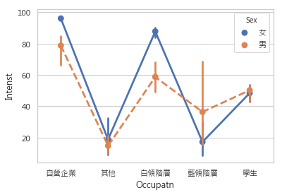

```python
sns.pointplot(x="Occupatn", y="Intenst", hue="Sex", data=Cafe, linestyles=["-", "--"])#交互作用圖
```

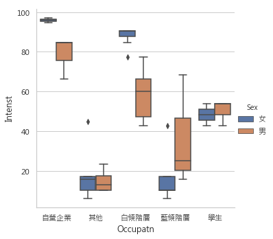

```python
sns.factorplot(x="Occupatn",  y="Intenst", hue="Sex", data=Cafe,
               kind="box")
```

```python
model.summary()
```

OLS Regression Results

| Dep. Variable: | Intenst | R-squared: | 0.869 |
| --- | --- | --- | --- |
| Model: | OLS | Adj. R-squared: | 0.829 |
| Method: | Least Squares | F-statistic: | 22.04 |
| Date: | Tue, 26 Mar 2019 | Prob (F-statistic): | 6.89e-11 |
| Time: | 10:29:55 | Log-Likelihood: | -153.25 |
| No. Observations: | 40 | AIC: | 326.5 |
| Df Residuals: | 30 | BIC: | 343.4 |
| Df Model: | 9 |  |  |
| Covariance Type: | nonrobust |  |  |

|  | coef | std err | t | P>\|t\| | [0.025 | 0.975] |
| --- | --- | --- | --- | --- | --- | --- |
| Intercept | 18.7578 | 5.763 | 3.255 | 0.003 | 6.989 | 30.527 |
| C(Sex)[T.男] | -3.9967 | 8.644 | -0.462 | 0.647 | -21.650 | 13.657 |
| C(Occupatn)[T.學生] | 29.6267 | 10.781 | 2.748 | 0.010 | 7.609 | 51.644 |
| C(Occupatn)[T.白領階層] | 69.0054 | 7.545 | 9.146 | 0.000 | 53.596 | 84.414 |
| C(Occupatn)[T.自營企業] | 77.2790 | 10.781 | 7.168 | 0.000 | 55.262 | 99.297 |
| C(Occupatn)[T.藍領階層] | -1.5637 | 8.150 | -0.192 | 0.849 | -18.207 | 15.080 |
| C(Sex)[T.男]:C(Occupatn)[T.學生] | 5.8214 | 14.597 | 0.399 | 0.693 | -23.990 | 35.633 |
| C(Sex)[T.男]:C(Occupatn)[T.白領階層] | -25.0690 | 11.230 | -2.232 | 0.033 | -48.003 | -2.134 |
| C(Sex)[T.男]:C(Occupatn)[T.自營企業] | -13.3208 | 14.597 | -0.913 | 0.369 | -43.133 | 16.491 |
| C(Sex)[T.男]:C(Occupatn)[T.藍領階層] | 23.1557 | 12.778 | 1.812 | 0.080 | -2.940 | 49.251 |

| Omnibus: | 8.593 | Durbin-Watson: | 1.863 |
| --- | --- | --- | --- |
| Prob(Omnibus): | 0.014 | Jarque-Bera (JB): | 7.438 |
| Skew: | 0.925 | Prob(JB): | 0.0243 |
| Kurtosis: | 4.020 | Cond. No. | 14.7 |

Warnings:  
[1] Standard Errors assume that the covariance matrix of the errors is correctly specified.

```python
## 各群不同的平均值是多少

pd.crosstab(Cafe.Occupatn, Cafe.Sex, values=Cafe.Intenst, aggfunc='mean').round(2) #取不同組別的平均數，小數點以下兩位
```

| Sex Occupatn | 女 | 男 |
| --- | --- | --- |
| 其他 | 18.76 | 14.76 |
| 學生 | 48.38 | 50.21 |
| 白領階層 | 87.76 | 58.70 |
| 自營企業 | 96.04 | 78.72 |
| 藍領階層 | 17.19 | 36.35 |

[figure not shown]

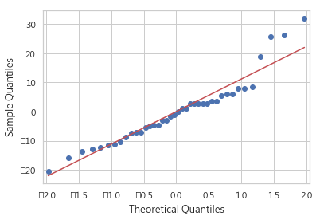

```python
#Our model fit (the linear model fitted with the OLS method) and get a Quantile-Quantile (QQplot):
res = model.resid
fig = sm.qqplot(res, line='s')
plt.show()
```

### [小結]: **Reject H0。在α = 0.05下，我們有顯著的證據認為，不同職業與不同性別，對產品強度有顯著影響**

### [管理意涵]

- **自營女性、白領女性、自營男性。三者的產品強度最高**
- **簡而言之，左岸咖啡可以利用職業及性別來區隔市場，實證結果顯示，自營女性、白領女性、自營男性。三者的產品強度最高，應是為目標市場，其餘七個職業性別組合則被視為非目標市場，行銷人員應依據這三群的目標市場特質，設計左岸咖啡之行銷策略。**

### [補充:為將來做準備 ]. 我們新建一個分群變數!

> - Segment
>   - 1.自營企業
>   - 2.白領階層
>   - 3.學生、籃領、其它

```python
Cafe["Segment"] = Cafe[["Occupatn"]] #新增一個 Segment欄位，內容是Occupatn的內容
Cafe.sample(10)#隨機取10行
```

|  | ID | A101左岸頻率 | A102伯朗頻率 | A103廣場頻率 | A104輕鬆頻率 | A2咖啡偏好 | A3偏好口味 | A401提神醒腦 | A402習慣飲用 | A403抒解口渴 | ... | Sex | AGE | Occupatn | Edu | Income0 | IncomeMd | Area | Intenst | Gender | Segment |
| --- | --- | --- | --- | --- | --- | --- | --- | --- | --- | --- | --- | --- | --- | --- | --- | --- | --- | --- | --- | --- | --- |
| 35 | 36 | 1 | 0 | 2 | 0 | 6 | 加糖及奶精之香濃口味 | 6 | 6 | 4 | ... | 男 | 4 | 自營企業 | 高中(職) | 6萬以上 | 6.5 | 南部 | 66.4761 | 男 | 自營企業 |
| 19 | 20 | 0 | 1 | 2 | 0 | 7 | 偏苦之咖啡原味 | 7 | 7 | 4 | ... | 男 | 4 | 白領階層 | 研究所 | 3-4萬 | 3.5 | 北部 | 53.8586 | 男 | 白領階層 |
| 27 | 28 | 0 | 1 | 0 | 0 | 2 | 加糖及奶精之香濃口味 | 5 | 4 | 4 | ... | 女 | 3 | 藍領階層 | 高中(職) | 2-3萬 | 2.5 | 北部 | 10.0137 | 女 | 藍領階層 |
| 9 | 10 | 2 | 1 | 1 | 0 | 4 | 加糖及奶精之香濃口味 | 5 | 6 | 2 | ... | 男 | 4 | 藍領階層 | 專科及大學 | 2-3萬 | 2.5 | 北部 | 68.3881 | 男 | 藍領階層 |
| 38 | 39 | 2 | 0 | 1 | 0 | 5 | 加糖及奶精之香濃口味 | 5 | 5 | 3 | ... | 女 | 3 | 白領階層 | 高中(職) | 5-6萬 | 5.5 | 中部 | 77.4608 | 女 | 白領階層 |
| 24 | 25 | 0 | 2 | 0 | 0 | 6 | 偏苦之咖啡原味 | 7 | 6 | 4 | ... | 男 | 1 | 學生 | 國中 | 1萬以下 | 0.5 | 中部 | 42.9104 | 男 | 學生 |
| 5 | 6 | 0 | 1 | 0 | 0 | 2 | 偏苦之咖啡原味 | 5 | 5 | 5 | ... | 女 | 3 | 其他 | 高中(職) | 1-2萬 | 1.5 | 北部 | 10.0137 | 女 | 其他 |
| 21 | 22 | 2 | 1 | 0 | 0 | 5 | 加糖及奶精之香濃口味 | 5 | 5 | 3 | ... | 男 | 2 | 白領階層 | 專科及大學 | 3-4萬 | 3.5 | 南部 | 77.4608 | 男 | 白領階層 |
| 20 | 21 | 1 | 0 | 0 | 0 | 4 | 加糖及奶精之香濃口味 | 5 | 4 | 4 | ... | 女 | 5 | 其他 | 高中(職) | 1-2萬 | 1.5 | 中部 | 45.0037 | 女 | 其他 |
| 17 | 18 | 2 | 1 | 1 | 0 | 6 | 加糖及奶精之香濃口味 | 6 | 6 | 3 | ... | 男 | 4 | 自營企業 | 研究所 | 6萬以上 | 6.5 | 北部 | 84.8410 | 男 | 自營企業 |

10 rows × 95 columns

```python
Cafe["Segment"] = Cafe["Segment"].str.replace("學生","其他")
Cafe["Segment"] = Cafe["Segment"].str.replace("藍領階層","其他")
Cafe.sample(10)#隨機取10行
#所以現在Segment只有三種類別: 自營企業、白領階層、其他
```

|  | ID | A101左岸頻率 | A102伯朗頻率 | A103廣場頻率 | A104輕鬆頻率 | A2咖啡偏好 | A3偏好口味 | A401提神醒腦 | A402習慣飲用 | A403抒解口渴 | ... | Sex | AGE | Occupatn | Edu | Income0 | IncomeMd | Area | Intenst | Gender | Segment |
| --- | --- | --- | --- | --- | --- | --- | --- | --- | --- | --- | --- | --- | --- | --- | --- | --- | --- | --- | --- | --- | --- |
| 4 | 5 | 1 | 0 | 0 | 0 | 1 | 加糖及奶精之香濃口味 | 3 | 3 | 3 | ... | 女 | 2 | 藍領階層 | 國中 | 1-2萬 | 1.5 | 北部 | 17.0509 | 女 | 其他 |
| 21 | 22 | 2 | 1 | 0 | 0 | 5 | 加糖及奶精之香濃口味 | 5 | 5 | 3 | ... | 男 | 2 | 白領階層 | 專科及大學 | 3-4萬 | 3.5 | 南部 | 77.4608 | 男 | 白領階層 |
| 35 | 36 | 1 | 0 | 2 | 0 | 6 | 加糖及奶精之香濃口味 | 6 | 6 | 4 | ... | 男 | 4 | 自營企業 | 高中(職) | 6萬以上 | 6.5 | 南部 | 66.4761 | 男 | 自營企業 |
| 3 | 4 | 2 | 0 | 3 | 0 | 7 | 加糖及奶精之香濃口味 | 7 | 6 | 4 | ... | 女 | 3 | 白領階層 | 專科及大學 | 4-5萬 | 4.5 | 北部 | 90.4082 | 女 | 白領階層 |
| 28 | 29 | 0 | 0 | 1 | 0 | 2 | 偏苦之咖啡原味 | 5 | 4 | 4 | ... | 男 | 5 | 其他 | 專科及大學 | 2-3萬 | 2.5 | 北部 | 10.0137 | 男 | 其他 |
| 19 | 20 | 0 | 1 | 2 | 0 | 7 | 偏苦之咖啡原味 | 7 | 7 | 4 | ... | 男 | 4 | 白領階層 | 研究所 | 3-4萬 | 3.5 | 北部 | 53.8586 | 男 | 白領階層 |
| 7 | 8 | 1 | 0 | 0 | 0 | 2 | 偏苦之咖啡原味 | 4 | 4 | 3 | ... | 男 | 2 | 藍領階層 | 高中(職) | 1-2萬 | 1.5 | 北部 | 24.9322 | 男 | 其他 |
| 26 | 27 | 2 | 0 | 3 | 0 | 7 | 加糖及奶精之香濃口味 | 7 | 6 | 2 | ... | 女 | 3 | 白領階層 | 專科及大學 | 4-5萬 | 4.5 | 北部 | 90.4082 | 女 | 白領階層 |
| 10 | 11 | 2 | 3 | 0 | 0 | 7 | 加糖及奶精之香濃口味 | 7 | 7 | 3 | ... | 女 | 4 | 白領階層 | 高中(職) | 4-5萬 | 4.5 | 南部 | 90.4082 | 女 | 白領階層 |
| 31 | 32 | 1 | 0 | 0 | 0 | 4 | 加糖及奶精之香濃口味 | 3 | 4 | 3 | ... | 男 | 4 | 白領階層 | 專科及大學 | 4-5萬 | 4.5 | 南部 | 45.0037 | 男 | 白領階層 |

10 rows × 95 columns

## [PART 5]. 左岸咖啡之所得定位 (Multiple Regression)

- 在前面，我們已經Income0 轉成IncomeMd
- 此時的 IncomeMd 是Ratio Scale
- 因此本小節，我們要用Regresion 看看**個人所得、咖啡偏好對左岸咖啡的使用頻率沒有影響**
- 在使用迴歸時，建議一個model一個model跑，比較清楚
- 所以接下來的流程是:
  - Model-1: 個人所得對使用頻率
  - Model-2: 咖啡偏好對使用頻率
  - Model-3: 個人所得、咖啡偏好對使用頻率
- **H0e:個人所得、咖啡偏好對左岸咖啡的使用頻率沒有影響**
- **H1e:個人所得、咖啡偏好對左岸咖啡的使用頻率有影響**

### [Model 1]. 個人所得對使用頻率

```python
Cafe.IncomeMd.mean() #所得均值
```

```
3.275
```

```python
Cafe.A101左岸頻率.mean() #左岸頻率均值
```

```
0.9
```

```python
import statsmodels.api as sm
import statsmodels.formula.api as smf

results = smf.ols('A101左岸頻率 ~ IncomeMd', data=Cafe).fit() #簡單迴歸
print(results.summary())
```

```
                            OLS Regression Results
==============================================================================
Dep. Variable:               A101左岸頻率   R-squared:                       0.549
Model:                            OLS   Adj. R-squared:                  0.537
Method:                 Least Squares   F-statistic:                     46.24
Date:                Tue, 26 Mar 2019   Prob (F-statistic):           4.60e-08
Time:                        10:31:18   Log-Likelihood:                -39.599
No. Observations:                  40   AIC:                             83.20
Df Residuals:                      38   BIC:                             86.58
Df Model:                           1
Covariance Type:            nonrobust
==============================================================================
                 coef    std err          t      P>|t|      [0.025      0.975]
------------------------------------------------------------------------------
Intercept     -0.5662      0.240     -2.358      0.024      -1.052      -0.080
IncomeMd       0.4477      0.066      6.800      0.000       0.314       0.581
==============================================================================
Omnibus:                        1.457   Durbin-Watson:                   2.208
Prob(Omnibus):                  0.483   Jarque-Bera (JB):                1.269
Skew:                           0.421   Prob(JB):                        0.530
Kurtosis:                       2.770   Cond. No.                         8.80
==============================================================================

Warnings:
[1] Standard Errors assume that the covariance matrix of the errors is correctly specified.
```

### [Model 2]. 咖啡偏好對使用頻率

```python
Cafe.A2咖啡偏好.mean() #咖啡偏好均值
```

```
4.675
```

```python
results2 = smf.ols('A101左岸頻率 ~ A2咖啡偏好', data=Cafe).fit() #簡單迴歸
print(results2.summary())
```

```
                            OLS Regression Results
==============================================================================
Dep. Variable:               A101左岸頻率   R-squared:                       0.177
Model:                            OLS   Adj. R-squared:                  0.155
Method:                 Least Squares   F-statistic:                     8.181
Date:                Tue, 26 Mar 2019   Prob (F-statistic):            0.00684
Time:                        10:31:24   Log-Likelihood:                -51.620
No. Observations:                  40   AIC:                             107.2
Df Residuals:                      38   BIC:                             110.6
Df Model:                           1
Covariance Type:            nonrobust
==============================================================================
                 coef    std err          t      P>|t|      [0.025      0.975]
------------------------------------------------------------------------------
Intercept      0.0026      0.345      0.008      0.994      -0.695       0.700
A2咖啡偏好         0.1920      0.067      2.860      0.007       0.056       0.328
==============================================================================
Omnibus:                        3.672   Durbin-Watson:                   1.973
Prob(Omnibus):                  0.159   Jarque-Bera (JB):                1.666
Skew:                           0.079   Prob(JB):                        0.435
Kurtosis:                       2.013   Cond. No.                         12.8
==============================================================================

Warnings:
[1] Standard Errors assume that the covariance matrix of the errors is correctly specified.
```

## [Model 3]. 個人所得、咖啡偏好對使用頻率

```python
results3 = smf.ols('A101左岸頻率 ~ A2咖啡偏好 + IncomeMd', data=Cafe).fit() #複迴歸
print(results3.summary())
```

```
                            OLS Regression Results
==============================================================================
Dep. Variable:               A101左岸頻率   R-squared:                       0.554
Model:                            OLS   Adj. R-squared:                  0.530
Method:                 Least Squares   F-statistic:                     22.97
Date:                Tue, 26 Mar 2019   Prob (F-statistic):           3.27e-07
Time:                        10:31:29   Log-Likelihood:                -39.375
No. Observations:                  40   AIC:                             84.75
Df Residuals:                      37   BIC:                             89.82
Df Model:                           2
Covariance Type:            nonrobust
==============================================================================
                 coef    std err          t      P>|t|      [0.025      0.975]
------------------------------------------------------------------------------
Intercept     -0.6614      0.283     -2.335      0.025      -1.235      -0.087
A2咖啡偏好         0.0370      0.057      0.646      0.522      -0.079       0.153
IncomeMd       0.4239      0.076      5.590      0.000       0.270       0.578
==============================================================================
Omnibus:                        1.340   Durbin-Watson:                   2.202
Prob(Omnibus):                  0.512   Jarque-Bera (JB):                1.132
Skew:                           0.400   Prob(JB):                        0.568
Kurtosis:                       2.805   Cond. No.                         16.8
==============================================================================

Warnings:
[1] Standard Errors assume that the covariance matrix of the errors is correctly specified.
```

### [註記].

- **由Model 3，你會發現當'IncomeMd'丟進去後，'A2咖啡偏好'不顯著了**
- **其實這表示，'IncomeMd'是中介變數**
- **但這不在初等統計學的授課範圍內，因此課堂上我們不多做說明**

### [PART 6]. 左岸咖啡之口味差異化策劃

> - **在本小節，我們要採用卡方獨立性檢定!**
> - **你應該還記得，之前我們曾經新建一個Segment(目標市場)的變數**
>   - 1.自營企業
>   - 2.白領階層
>   - 3.學生、籃領、其它
> - **目標市場、性別對口味偏好的影響**
>   - 變數定義
>     - 1.反應變量: **A3偏好口味**
>     - 2.解釋變數: **Sex**、**Segment**

### [6-1]. 我們先來看看原始的數據

```python
contingency_table1 = pd.crosstab(index=[Cafe['Occupatn'], Cafe['Sex']],
                    columns=Cafe["A3偏好口味"]
                             )
contingency_table1

#我們會發現有些格子的數值<5，表示要併組處理
```

| Occupatn | A3偏好口味 Sex | 偏苦之咖啡原味 | 加糖及奶精之香濃口味 |
| --- | --- | --- | --- |
| 其他 | 女 | 1 | 4 |
|  | 男 | 4 | 0 |
| 學生 | 女 | 1 | 1 |
|  | 男 | 3 | 0 |
| 白領階層 | 女 | 0 | 7 |
|  | 男 | 1 | 5 |
| 自營企業 | 女 | 0 | 2 |
|  | 男 | 1 | 2 |
| 藍領階層 | 女 | 1 | 4 |
|  | 男 | 2 | 1 |

### [6-2]. 併組之後的列聯表

- 以上的方式必須要每一格的數值都超過5
- 一旦沒有超過5。必須要併組
- 本Café的檔案總樣本為40，分配到各組之後會有某幾組不滿5
- 所以退而求其次用以下的方式處理
- 採用另一個依據職業類別修改的區隔變數**"Segment"**

```python
contingency_table2 = pd.crosstab(Cafe['Sex'], Cafe['A3偏好口味'])
contingency_table2
```

| A3偏好口味 Sex | 偏苦之咖啡原味 | 加糖及奶精之香濃口味 |
| --- | --- | --- |
| 女 | 3 | 18 |
| 男 | 11 | 8 |

```python
contingency_table3 = pd.crosstab(Cafe['Segment'], Cafe['A3偏好口味'])
contingency_table3
#因為本次練習的 Sample size只有40個，一定會有所不足，建議在大樣本的情況下應滿足 >5 之條件
```

| A3偏好口味 Segment | 偏苦之咖啡原味 | 加糖及奶精之香濃口味 |
| --- | --- | --- |
| 其他 | 12 | 10 |
| 白領階層 | 1 | 12 |
| 自營企業 | 1 | 4 |

### [6-3]. 卡方分析

### Q:目標市場與性別，對偏好口味之影響!

- **H1f: 不同性別之咖啡口味偏好有顯著差異**
- **H1g: 不同目標市場之咖啡口味偏好有顯著差異**

## [在開始卡方分析之前].先要引入**researchpy** 套件

### - conda install -c researchpy researchpy

```python
import pandas as pd
import researchpy as rp
from scipy import stats
```

```python
table1, results1 = rp.crosstab(Cafe['Sex'], Cafe['A3偏好口味'], prop= 'col', test= 'chi-square')

table1
```

| Sex | A3偏好口味 偏苦之咖啡原味 | A3偏好口味 加糖及奶精之香濃口味 | A3偏好口味 All |
| --- | --- | --- | --- |
| 女 | 21.43 | 69.23 | 52.5 |
| 男 | 78.57 | 30.77 | 47.5 |
| All | 100.00 | 100.00 | 100.0 |

```python
results1
```

|  | Chi-square test | results |
| --- | --- | --- |
| 0 | Pearson Chi-square ( 1.0) = | 8.3384 |
| 1 | p-value = | 0.0039 |
| 2 | Cramer's phi = | 0.4566 |

```python
table2, results2 = rp.crosstab(Cafe['Segment'], Cafe['A3偏好口味'], prop= 'col', test= 'chi-square')

table2
```

| Segment | A3偏好口味 偏苦之咖啡原味 | A3偏好口味 加糖及奶精之香濃口味 | A3偏好口味 All |
| --- | --- | --- | --- |
| 其他 | 85.71 | 38.46 | 55.0 |
| 白領階層 | 7.14 | 46.15 | 32.5 |
| 自營企業 | 7.14 | 15.38 | 12.5 |
| All | 100.00 | 100.00 | 100.0 |

```python
results2
```

|  | Chi-square test | results |
| --- | --- | --- |
| 0 | Pearson Chi-square ( 2.0) = | 8.4500 |
| 1 | p-value = | 0.0146 |
| 2 | Cramer's V = | 0.4596 |

### [小結]: **Reject Ho，在α=0.05下，我們有顯著的證據認為，不同目標市場與不同性別，對咖啡偏好口味有顯著差異。**

### [管理意涵]

- **本節假定目標市場與性別的交互作用不存在**
- **實證結果顯示，行銷研究人員可針對其他職業與男性推出偏好濃口味咖啡; 對白領階層、自營企業、女性推出偏好淡口味咖啡。**

### [最後說明]

> - 此份資料僅供教學用途，主要用以說明敘述統計及應用統計在Python之應用
> - 後續仍然可以用在其他的市場調查議題，若有興趣之同學，可於碩士班時修習"多變量分析"，會對市場調查及行銷研究會有更深的體驗
> - 本程式碼僅由本人撰寫，若有任何錯誤，請不吝提出，謝謝

### [資料來源]

- pandas-cheat-sheet https://www.dataquest.io/blog/pandas-cheat-sheet/
- Learning Pandas - 處理資料分組 https://ithelp.ithome.com.tw/articles/10200565?sc=iThelpR
- 癌症資料處理範例 http://viml.nchc.org.tw/blog/paper_info.php?CLASS_ID=1&SUB_ID=1&PAPER_ID=681
- Three ways to do a two-way ANOVA with Python https://www.marsja.se/three-ways-to-carry-out-2-way-anova-with-python/
- 卡方分析 https://pythonfordatascience.org/chi-square-test-of-independence-python/